# Results Section Three: Cooccurrence and Bigrams

# How do Black and White soldiers talk about gender roles?

In addition to analyzing race relations between soldiers, we want to see how gender roles were discussed amongst soldiers. Our particular focus is on women's gender roles during the time of 1943 and at the intersection of race relations.

A dictionary of gender words are loaded to identy which responses relate to gender topics.

```r
#load dictionary csv
gender_words <- fread("~/git/dspg2020amsoldier/data/dictionary/gender.csv", sep = ",");head(gender_words)
```

```
##         gender category
## 1: androgynous identity
## 2:    blackboi     male
## 3:   blackgirl   female
## 4:    blackman     male
## 5:  blackwoman   female
## 6:         boy     male
```

```r
gender_match <- paste(paste("\\b", gender_words$gender,"\\b", sep = ""), collapse="|") #regex friendly
```

### Main Findings

#### Which words do soldiers use to pair with female relating words?

In the long response question, soldiers are asked to give their feedback on any part of the questionnaire. Any and all aspects of the war were free to talk about.

```
## Using `n` as weighting variable
## ℹ Quiet this message with `wt = n` or count rows with `wt = 1`
```

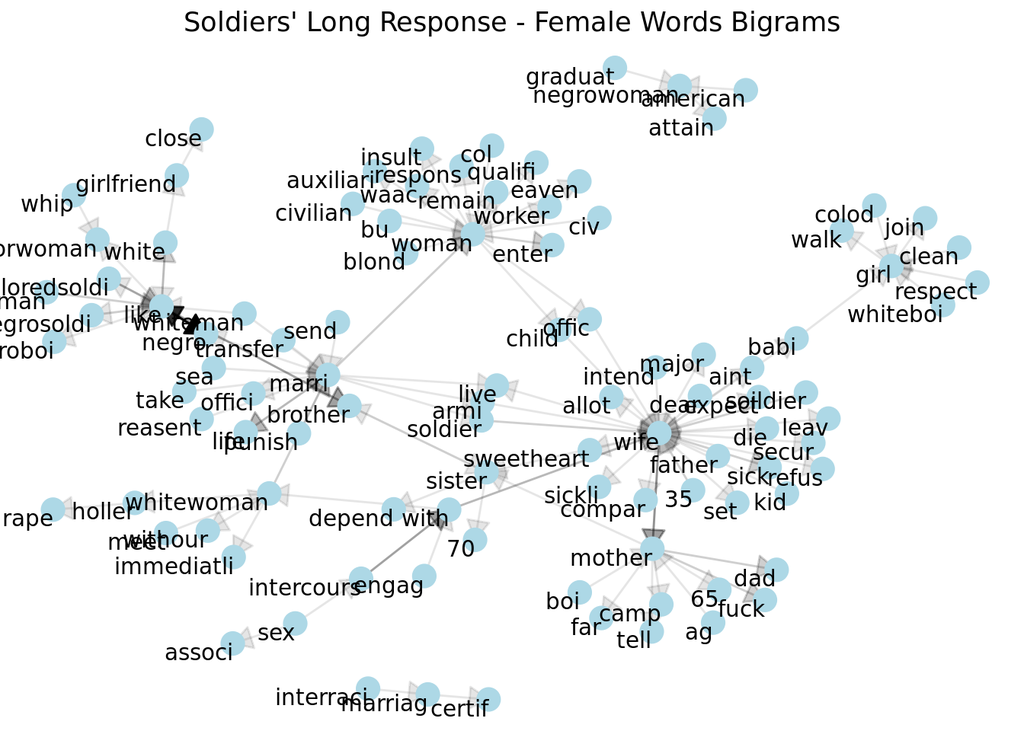

We can see at the like node there is a chain of "whiteman like colorwoman." There are also instances of whiteman are like black men/soldiers. This is either relating the two in similarity or in emotion of likeness between the two.

Another interesting addition to the network with relationship words is the chain of bigrams "sex intercourse with whitewoman". A hot topic was white soldiers being concerned with black soldiers having sexual relations with 'their' whitewomen. Likewise, black soldiers were aware of the tension of being falsely accused for raping or having sex with white women.

Otherwise, themes of family are prevelant for women's role in the commentary of the soldiers. We can also see the different pairings with the word woman, seeming to talk about their roles as workers amongst other attributes (worker, waac, auxiliary)

Lets see how these pairings differ between the white and black soldiers:

```
## Using `n` as weighting variable
## ℹ Quiet this message with `wt = n` or count rows with `wt = 1`
```

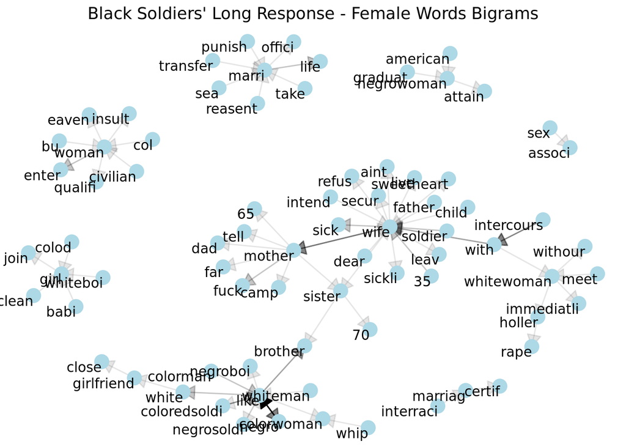

```
## Using `n` as weighting variable
## ℹ Quiet this message with `wt = n` or count rows with `wt = 1`
```

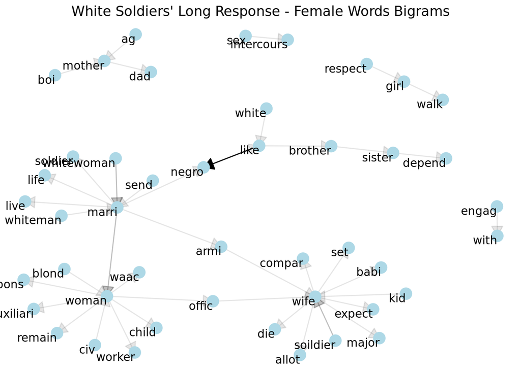

We see a complete lack of narrative in black women specifically. Conversations about women are mostly about their role in the family as a mother, wife or sister. Another common conversation is about working women, with pairings to WAAC, auxiliary (referring to WAAC) and worker.

#### Which words that soldiers use are correlated with female relating words?

An alternative to the method of bigrams, Co-occurrences measure the correlation of two words appearing with one another in a body of text. Unlike bigrams, these words do not have to appear directly next to one another, and their strength of association is measured.

First, we will look at which words are correlated with female words in all soldiers' long responses.

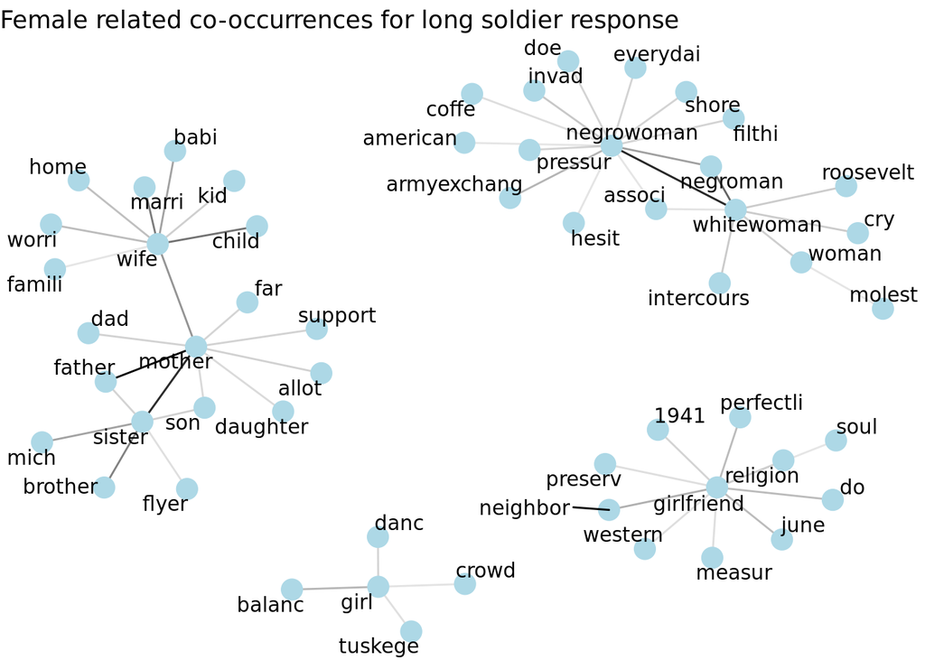

Themes of family are still prevelant. Negrowoman are associated with some negative words like filthy and invade. Whitewomen associations with the words intercourse, cry and molest are related to the controversy of black men having sexual realtions with whitemen. In addition, whitewomen is associated with negroman. This is shows that there is commentary of the association of black and white women which was controversial at the time.

Next, we will break it down by race.

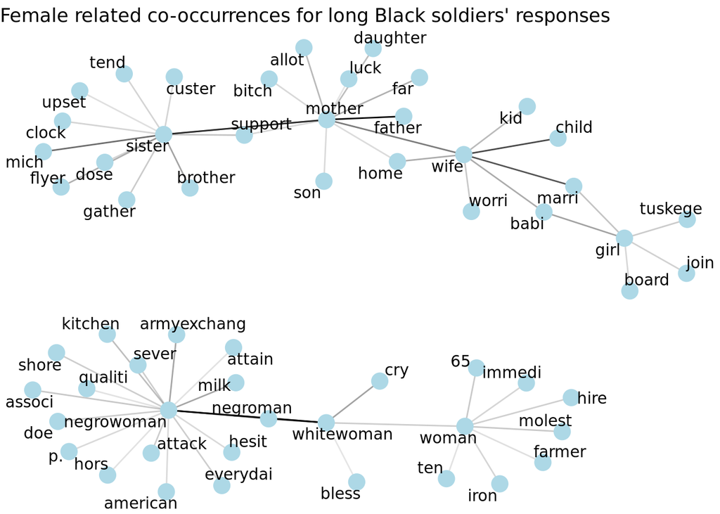

One of the strongest correlations are between negrowoman and negroman as well as negroman and whitewoman. This is indicative that interracial relations are one the most heavily correlated topics to women in the Black soldiers' responses. In addition, mother, sister and father have some of the strongest correlations, showing that women's most prevalent role for the soldiers was in their families.

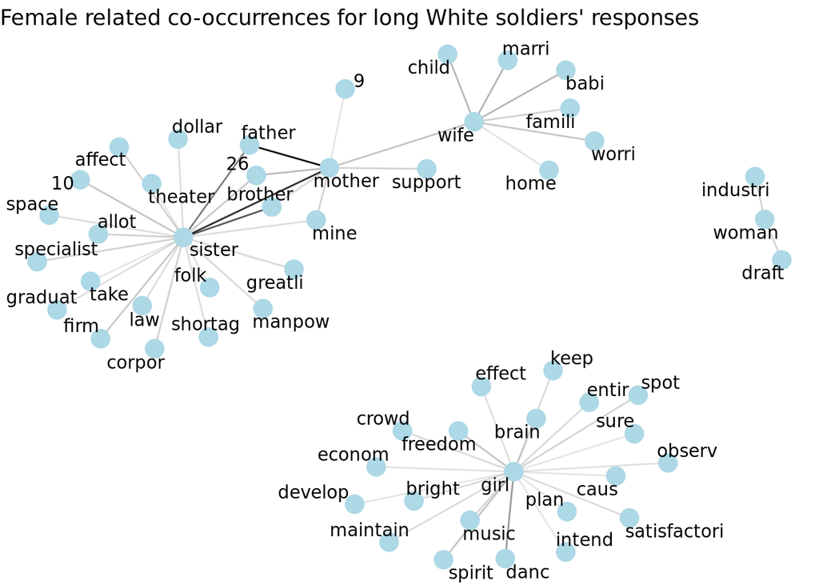

These words correlated with female words seem inherently random. This could be due to the fact that commentary about women were included in responses that talked about other various topics regarding the war and soldier life. However, we again see an absence of discussion about Black women as a whole.